# RNAmaps, Binding sites, k-mers

Mario Keller

Faculty of Biological Sciences, Goethe University Frankfurt

2 May 2023

```r
library(tidyverse)
library(knitr)
library(ggsci)
library(GenomicRanges)
library(plyranges)
library(rtracklayer)
library(Biostrings)
library(BSgenome.Hsapiens.UCSC.hg38)
library(ggseqlogo)
```

```r
myTheme <- theme_bw() +
    theme(axis.text = element_text(size = 10, colour="black"),
          axis.title = element_text(size=12, colour="black"),
          axis.ticks=element_line(color="black"),
          axis.ticks.length=unit(.15, "cm"),
          panel.border=element_rect(color="black", fill = NA),
          panel.background = element_blank(),
          plot.background = element_blank(),
          plot.title = element_text(size=12),
          legend.text = element_text(size=10),
          legend.position = "none")
```

# 1 Background

USP39 binding behavior and local features of A5SS events should be analyzed.

# 2 Data

Regulated and non-regulated A5SS events as well as USP39 binding sites are loaded from a RDS-Files. In addition, iCLIP crosslink events are loaded from BigWig-Files.

```r
A5SSranges <- readRDS("rds_files/A5SSranges.rds")
nonRegulatedA5SSranges <- readRDS("rds_files/nonRegA5SSranges.rds")
Xlinks_plus <- import("data/iCLIP/HEK293T_USP39_combined_L_plus.bw", as="Rle")
Xlinks_minus <- import("data/iCLIP/HEK293T_USP39_combined_L_minus.bw", as="Rle")

bindingSites <- readRDS("data/iCLIP/finalbindingSites.RDS")
```

# 3 Definition of canonical and alternative splice sites

In a first step, the canonical and alternative splice sites were defined for each A5SS event. For regulated events the canonical splice sites is the start position of the junction downregulated upon USP39 knockdown, while for non-regulated events it is the start position of the junction with the higher PSI value in the control condition. Events where the canonical splice site has a PSI < 0.5 in the control condition were not considered.

```r
# Regulated
canonicalSS <- endoapply(A5SSranges, function(gr){
    gr$exon_length <- width(gr)
    gr %>% plyranges::slice(which.min(KD.CT_median_dpsi))
}) %>% unlist %>% resize(., 1, fix="end")

alternativeSS <- endoapply(A5SSranges, function(gr){
    gr$exon_length <- width(gr)
    gr %>% plyranges::slice(which.max(KD.CT_median_dpsi))
}) %>% unlist %>% resize(., 1, fix="end")

# Non-regulated
nonRegCanonicalSS <- endoapply(nonRegulatedA5SSranges, function(gr){
    gr$exon_length <- width(gr)
    gr %>% plyranges::slice(which.max(CT_median_psi))
}) %>% unlist %>% resize(., 1, fix="end")

nonRegAlternativeSS <- endoapply(nonRegulatedA5SSranges, function(gr){
    gr$exon_length <- width(gr)
    gr %>% plyranges::slice(which.min(CT_median_psi))
}) %>% unlist %>% resize(., 1, fix="end")

# Events where the down-regulated junction has a PSI > 0.5
eventsToKeep <- canonicalSS$event_id[canonicalSS$CT_median_psi > 0.5]
canonicalSS <- canonicalSS %>% plyranges::filter(event_id %in% eventsToKeep)
alternativeSS <- alternativeSS %>% plyranges::filter(event_id %in% eventsToKeep)

eventsToKeep <- nonRegCanonicalSS$event_id[nonRegCanonicalSS$CT_median_psi > 0.5]
nonRegCanonicalSS <- nonRegCanonicalSS %>% plyranges::filter(event_id %in% eventsToKeep)
nonRegAlternativeSS <- nonRegAlternativeSS %>% plyranges::filter(event_id %in% eventsToKeep)
```

# 4 RNAmaps

At first, a -50 to +300 nt window around the canonical and alternative 5’ splice sites is opened. Next, crosslink events are determined for the 351 nt windows. Finally, the signal in each window is min-max normalized ( (x-min)/(max-min) ).

```r
minMaxNorm <- function(mat){
    mat <- apply(mat, 1, function(row){
        (row-min(row, na.rm=TRUE))/ (max(row, na.rm=TRUE)-min(row, na.rm=TRUE))
        }) %>% t
    mat[is.nan(mat)] <- 0
    return(mat)
}

create_matrix <- function(gr){

    window <- gr %>% promoters(., upstream = 50, downstream=301)

    window_plus <- window[strand(window) == "+"]
    window_minus <- window[strand(window) == "-"]

    windowXlinks_plus <- Xlinks_plus[window_plus] %>% as.matrix
    rownames(windowXlinks_plus) <- window_plus$exon
    windowXlinks_minus <- Xlinks_minus[window_minus] %>% as.matrix
    rownames(windowXlinks_minus) <- window_minus$exon
    windowXlinks_minus <- windowXlinks_minus[,ncol(windowXlinks_minus):1]
    windowXlinks <- rbind(windowXlinks_plus, windowXlinks_minus)

    windowXlinks_smoothed <- minMaxNorm(windowXlinks)

    return(windowXlinks_smoothed)
}

canonicalMatrix <- create_matrix(canonicalSS)
alternativeMatrix <- create_matrix(alternativeSS)
nonRegCanonicalMatrix <- create_matrix(nonRegCanonicalSS)
nonRegAlternativeMatrix <- create_matrix(nonRegAlternativeSS)
```

To idenify regions with significant differences between regulated and non-regulated splice sites, a 10 nt sliding window is moved through each 351 nt window and the signal averaged for each window position. The signals at each window position are then compared between regulated and non-regulated splice sites with a Wilcoxon rank sum test, followed by BH FDR correction. Positions were considered as significant if the FDR was $\le$ 0.025.

```r
get_significant_bins <- function(mat1, mat2){

    binSize <- 10

    # Determine significant bins for each of the four splice sites

    # 10 nt bins are defined and the average signal determined for each
    #   CE event. Averages are compared between cooperatively regulated
    #   and the matched non-regulated CEe events using wilcox.test, followed
    #   by FDR correction
    FDR <- sapply(1:(351-binSize+1), function(i){
        wilcox.test(mat1[,i:(i+binSize-1)] %>% rowMeans(., na.rm = T),
                    mat2[,i:(i+binSize-1)] %>% rowMeans(., na.rm = T),
                    alternative="greater")$p.value}) %>%
        p.adjust(., method = "BH")

    # Final data.frame contains all significant bins (FDR <= 0.01)
    significantBins <- data.frame(
        binStart = 1:(351-binSize+1),
        binEnd = 1:(351-binSize+1)+(binSize-1),
        FDR = FDR
    ) %>% dplyr::filter(FDR <= 0.025)

    return(significantBins)
}

significantBinsCanonical <- get_significant_bins(canonicalMatrix, nonRegCanonicalMatrix)
significantBinsAlternative <- get_significant_bins(alternativeMatrix, nonRegAlternativeMatrix)

significantBinsCanonical$type <- factor("canonical", levels=c("canonical", "alternative"))
significantBinsAlternative$type <- factor("alternative", level=c("canonical", "alternative"))

significantBins <- rbind(significantBinsCanonical, significantBinsAlternative)
significantBins$binStart <- significantBins$binStart-51
significantBins$binEnd <- significantBins$binEnd-51
```

In the next step, the signal at each position is summarized via colMeans() and the respective RNA splice Maps plotted. Significant 10nt windows are shown at the top.

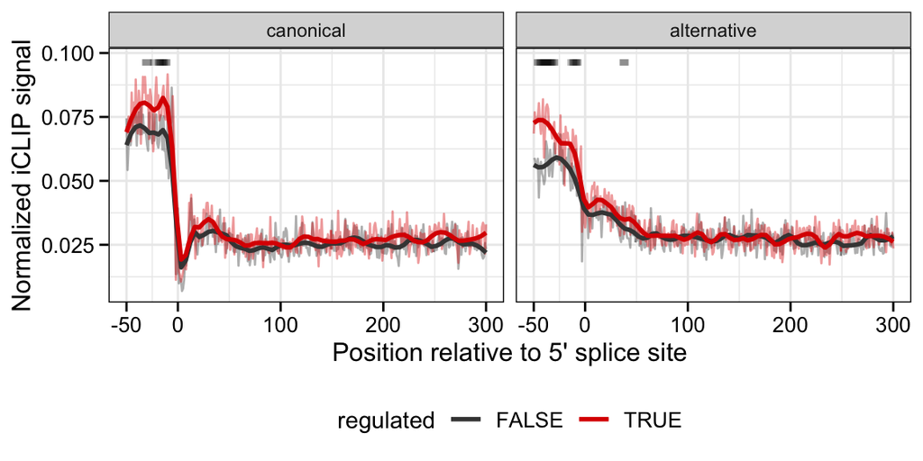

```r
p <- data.frame(pos=rep(-50:300, 4),
                 signal=c(canonicalMatrix %>% colMeans,
                          alternativeMatrix %>% colMeans,
                          nonRegCanonicalMatrix %>% colMeans,
                          nonRegAlternativeMatrix %>% colMeans),
                 type=factor(
                     c(rep("canonical", 351), rep("alternative", 351)),
                     levels=c("canonical", "alternative")),
                 regulated = c(rep(T, 351), rep(T, 351), rep(F, 351), rep(F, 351))) %>%
    ggplot(., aes(x=pos, y=signal, col=regulated)) +
        geom_line(alpha=0.4, size=.5) +
        geom_smooth(se=FALSE, method = "loess", span = 0.1, size=1) +
        facet_wrap(~type) +
        scale_color_manual(values=c("TRUE"="#DC0000",
                                    "FALSE" = "#444444")) +
        scale_x_continuous(breaks=c(-50, 0, 100, 200, 300)) +
        labs(x="Position relative to 5' splice site",
             y="Normalized iCLIP signal") +
        myTheme +
        theme(legend.position = "bottom")

p <- p + geom_rect(data=significantBins,
                   mapping=aes(xmin=binStart, xmax=binEnd,
                               ymin=0.095, ymax=0.0975),
                   fill="black", inherit.aes = FALSE,alpha=.25)
p
```

# 5 Binding sites

## 5.1 Logoplot

All 30120 binding sites are used for the generation of a logo plot, which reflects the nucleotide composition at the binding sites.

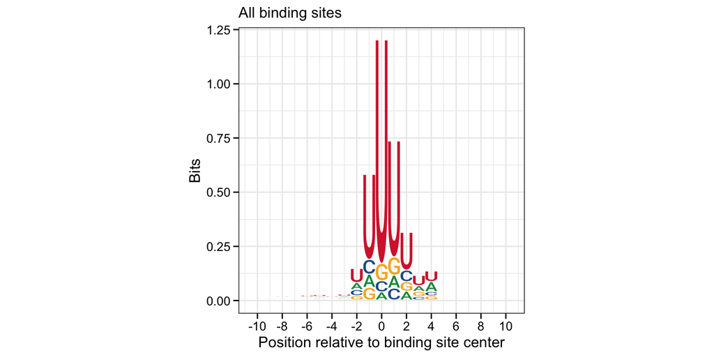

```r
rss <-RNAStringSet(getSeq(Hsapiens, bindingSites+8))
p <- ggplot() +
    geom_logo(as.character(rss), seq_type="rna", method="bits") +
    scale_x_continuous(breaks = seq(1,21,2), labels = seq(-10, 10, 2)) +
    labs(x="Position relative to binding site center", title = "All binding sites") +
    myTheme +
    theme(aspect.ratio = 1/1)
p
```

## 5.2 Tetramers around strong and weak binding sites

To check for an enrichment of tetramers around strong binding sites, a +/- 50 nt window is opened around each binding site ceter, followed by the counting of all tetramers in the 101 nt window.

In the next step, the top20 and bottom20 binding sites (picked by strength) are picked and for each set the mean tetramer frequency of each tetramer computed. These mean tetramer frequencies were used for the scatter plot shown below.

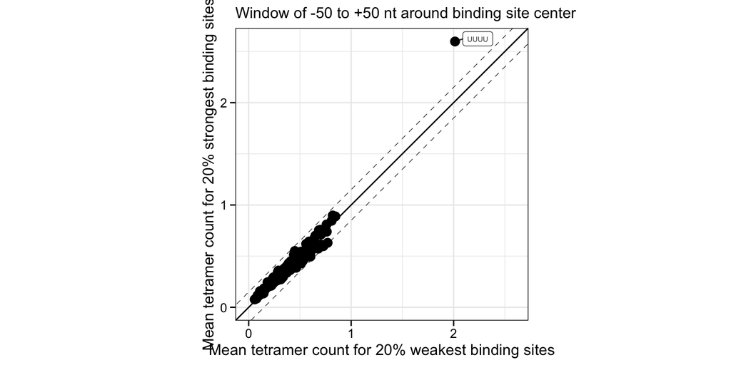

```r
bindingSites$rank <- cut(bindingSites$scoreMax,
                         breaks=quantile(bindingSites$scoreMax,
                                         probs=c(0, 0.2, 0.8, 1.0)),
                         labels=c("bottom20%", "others", "top20%"),
                         include.lowest = T)

top20 <- (bindingSites %>% plyranges::filter(rank == "top20%"))+48
bottom20 <- (bindingSites %>% plyranges::filter(rank == "bottom20%"))+48

top20RSS <- RNAStringSet(getSeq(Hsapiens, top20))
bottom20RSS <- RNAStringSet(getSeq(Hsapiens, bottom20))

data.frame(top20 = oligonucleotideFrequency(top20RSS, 4) %>% colMeans(),
           bottom20 = oligonucleotideFrequency(bottom20RSS, 4) %>% colMeans(),
           tetramer = oligonucleotideFrequency(RNAStringSet(), 4) %>% colnames) %>%
    mutate(tetramer = ifelse(abs(top20 - bottom20) < 0.15, "", tetramer)) %>%
    ggplot(., aes(x=bottom20, y=top20)) +
        geom_point(size=3) +
        geom_abline(slope=1, intercept=0) +
        geom_abline(slope=1, intercept=0.15, linetype="dashed", linewidth=.2) +
        geom_abline(slope=1, intercept=-0.15, linetype="dashed", linewidth=.2) +
        ggrepel::geom_label_repel(mapping=aes(x=bottom20, y=top20, label=tetramer), size=2, alpha=.8, inherit.aes = FALSE, max.overlaps=Inf, min.segment.length=.1, box.padding = .2, force=100) +
        labs(x="Mean tetramer count for 20% weakest binding sites",
             y="Mean tetramer count for 20% strongest binding sites",
             title="Window of -50 to +50 nt around binding site center") +
        coord_cartesian(xlim=c(0, 2.6), ylim=c(0, 2.6)) +
        theme(plot.title = element_text(size = 10, hjust=.5)) +
        guides(fill = guide_legend(title="Tetramer", title.position = "top", title.hjust = 0.5, ncol=2)) +
        myTheme +
        theme(aspect.ratio = 1/1)
```

# 6 A5SS events and binding sites

## 6.1 Binding site assignment

To check for close-by binding sites around canonical regulated and non-regulated alternative 5’ splice sites, at first, the read support of the underlying event is loaded. Read support means the sum of junction counts for the two junctions of each event across the two control experiments.

```r
A5SSreadSupport <- readRDS("rds_files/A5SSreadSupport.rds")
nonRegA5SSreadSupport <- readRDS("rds_files/nonRegA5SSreadSupport.rds")
```

```r
assignOverlappingBindingSites <- function(gr, width, set) {
    gr <- gr+width
    gr$set <- set
    gr$facet <- width
    gr$nBSs <- countOverlaps(gr, bindingSites)
    return(gr %>% as.data.frame)
}
```

In the next step, the fraction of canonical 5’ splice sites with at least one binding site overlapping a +/- 100 nt window around the splice sites is determined with respect to different read support cutoffs. The number of canonical splice sites at each cutoff is shown for the regulated and non-regulated splice sites in a barchart.

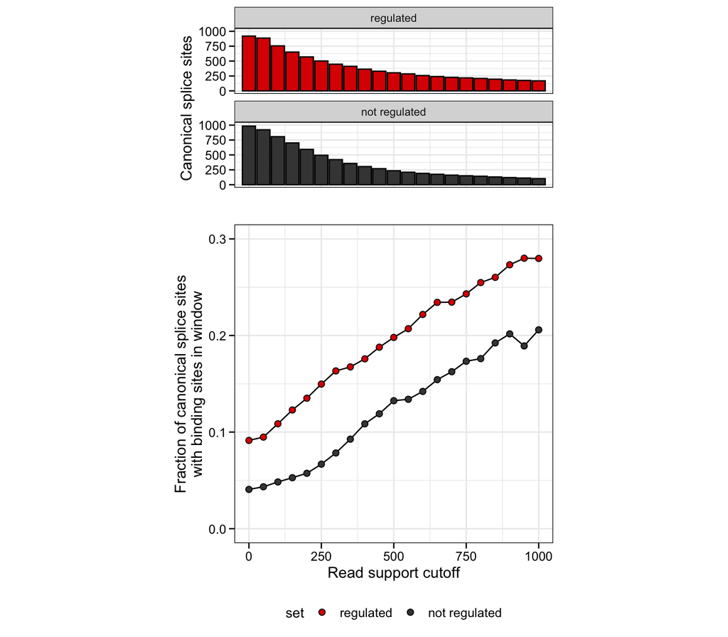

```r
assignOverlappingBindingSites <- function(gr, width, set, bindingSiteRegion) {

    if(bindingSiteRegion == "all"){
        BSs <- bindingSites
    } else if(bindingSiteRegion == "exonic"){
        BSs <- bindingSites %>% plyranges::filter(region %in% c("CDS", "UTR5", "UTR3"))
    } else {
        BSs <- bindingSites %>% plyranges::filter(region == "Intron")
    }

    if(set == "regulated"){
        gr$readSupport <- A5SSreadSupport$readSupport[match(gr$event_id, A5SSreadSupport$event_id)]
    } else {
        gr$readSupport <- nonRegA5SSreadSupport$readSupport[match(gr$event_id, nonRegA5SSreadSupport$event_id)]
    }

    gr <- gr+width
    gr$set <- set
    gr$facet <- width

    cutoffs <- seq(0,2000, 50)
    lapply(cutoffs, function(cutoff){
        tmpGR <- gr %>% plyranges::filter(gr$readSupport > cutoff)
        withOverlap <- sum(countOverlaps(tmpGR, BSs) > 0)
        data.frame(cutoff,
                   total=length(tmpGR),
                   withBS=withOverlap/length(tmpGR),
                   width,
                   set=factor(set, levels=c("regulated", "not regulated")))
    }) %>% bind_rows()
}


plotDFallBSs <- rbind(
    assignOverlappingBindingSites(canonicalSS, 50, "regulated", "all"),
    assignOverlappingBindingSites(nonRegCanonicalSS, 50, "not regulated", "all"),
    assignOverlappingBindingSites(canonicalSS, 100, "regulated", "all"),
    assignOverlappingBindingSites(nonRegCanonicalSS, 100, "not regulated", "all"),
    assignOverlappingBindingSites(canonicalSS, 250, "regulated", "all"),
    assignOverlappingBindingSites(nonRegCanonicalSS, 250, "not regulated", "all"),
    assignOverlappingBindingSites(canonicalSS, 500, "regulated", "all"),
    assignOverlappingBindingSites(nonRegCanonicalSS, 500, "not regulated", "all")
)

p1 <- plotDFallBSs %>%
    dplyr::filter(width==100, cutoff <= 1000) %>%
    ggplot(., aes(x=cutoff, y=total, fill=set)) +
        geom_col(col="black") +
        labs(x="", y="Canonical splice sites") +
        facet_wrap(~set, nrow=2) +
        scale_fill_manual(values=c("regulated" = "#DC0000",
                                    "not regulated" = "#444444")) +
        myTheme +
        coord_cartesian(xlim=c(0,1000), ylim=c(0,1000)) +
        theme(aspect.ratio=1/2,
              axis.text.x = element_blank(),
              axis.ticks.x = element_blank())

p2 <- plotDFallBSs %>%
    dplyr::filter(width==100, cutoff <= 1000) %>%
    ggplot(., aes(x=cutoff, y=withBS, fill=set)) +
        geom_line() +
        geom_point(pch=21, size=2, col="black") +
        scale_fill_manual(values=c("regulated" = "#DC0000",
                                    "not regulated" = "#444444")) +
        labs(x="Read support cutoff", y="Fraction of canonical splice sites\nwith binding sites in window") +
        coord_cartesian(ylim=c(0,0.3), xlim=c(0,1000)) +
        myTheme +
        theme(legend.position = "bottom",
              aspect.ratio = 1)

egg::ggarrange(p1, p2, nrow = 2)
```

The fraction of splice sites with an overlapping binding site when no cutoff is set is shown as stacked barchart.

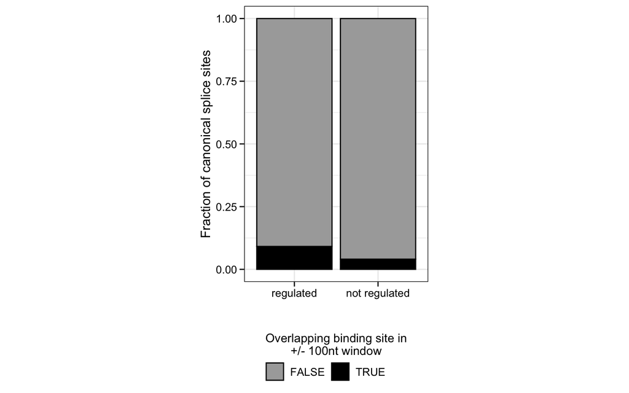

```r
plotDFallBSs %>%
    dplyr::filter(width==100, cutoff == 0) %>%
    mutate(withoutBS = 1-withBS) %>%
    pivot_longer(., cols=c("withBS", "withoutBS"), values_to="Fraction", names_to="hasBS") %>%
    mutate(hasBS = factor(hasBS, levels=c("withoutBS", "withBS"))) %>%
    ggplot(., aes(x=set, y=Fraction, fill=hasBS)) +
        geom_col(col="black") +
        scale_fill_manual(values=c("withBS" = "black",
                                   "withoutBS" = "darkgrey"),
                          labels=c("withBS"= "TRUE",
                                   "withoutBS" = "FALSE")) +
        labs(x="", y="Fraction of canonical splice sites") +
        guides(fill = guide_legend(title="Overlapping binding site in\n+/- 100nt window", title.position = "top", title.hjust = 0.5, ncol=2)) +
        myTheme +
        theme(aspect.ratio = 1.5/1,
              legend.position="bottom")
```

The underlying data.frame for plotting is shown below.

```r
plotDFallBSs %>%
    dplyr::filter(width==100, cutoff <= 1000) %>%
    kable(., "html") %>%
    kableExtra::kable_styling("striped") %>%
    kableExtra::scroll_box(height="300px", width = "94%")
```

| cutoff | total | withBS | width | set |
| --- | --- | --- | --- | --- |
| 0 | 919 | 0.0914037 | 100 | regulated |
| 50 | 886 | 0.0948081 | 100 | regulated |
| 100 | 755 | 0.1086093 | 100 | regulated |
| 150 | 651 | 0.1228879 | 100 | regulated |
| 200 | 570 | 0.1350877 | 100 | regulated |
| 250 | 501 | 0.1497006 | 100 | regulated |
| 300 | 447 | 0.1633110 | 100 | regulated |
| 350 | 412 | 0.1674757 | 100 | regulated |
| 400 | 364 | 0.1758242 | 100 | regulated |
| 450 | 330 | 0.1878788 | 100 | regulated |
| 500 | 303 | 0.1980198 | 100 | regulated |
| 550 | 285 | 0.2070175 | 100 | regulated |
| 600 | 257 | 0.2217899 | 100 | regulated |
| 650 | 239 | 0.2343096 | 100 | regulated |
| 700 | 226 | 0.2345133 | 100 | regulated |
| 750 | 218 | 0.2431193 | 100 | regulated |
| 800 | 208 | 0.2548077 | 100 | regulated |
| 850 | 196 | 0.2602041 | 100 | regulated |
| 900 | 183 | 0.2732240 | 100 | regulated |
| 950 | 175 | 0.2800000 | 100 | regulated |
| 1000 | 168 | 0.2797619 | 100 | regulated |
| 0 | 984 | 0.0406504 | 100 | not regulated |
| 50 | 922 | 0.0433839 | 100 | not regulated |
| 100 | 806 | 0.0483871 | 100 | not regulated |
| 150 | 701 | 0.0527817 | 100 | not regulated |
| 200 | 593 | 0.0573356 | 100 | not regulated |
| 250 | 494 | 0.0668016 | 100 | not regulated |
| 300 | 421 | 0.0783848 | 100 | not regulated |
| 350 | 356 | 0.0926966 | 100 | not regulated |
| 400 | 304 | 0.1085526 | 100 | not regulated |
| 450 | 269 | 0.1189591 | 100 | not regulated |
| 500 | 234 | 0.1324786 | 100 | not regulated |
| 550 | 209 | 0.1339713 | 100 | not regulated |
| 600 | 190 | 0.1421053 | 100 | not regulated |
| 650 | 175 | 0.1542857 | 100 | not regulated |
| 700 | 160 | 0.1625000 | 100 | not regulated |
| 750 | 150 | 0.1733333 | 100 | not regulated |
| 800 | 142 | 0.1760563 | 100 | not regulated |
| 850 | 130 | 0.1923077 | 100 | not regulated |
| 900 | 119 | 0.2016807 | 100 | not regulated |
| 950 | 111 | 0.1891892 | 100 | not regulated |
| 1000 | 102 | 0.2058824 | 100 | not regulated |

# 7 A5SS events

## 7.1 Tetramer analysis around regulated and non-regulated canonical A5SSs

Similar to the tetramer plot for strong against weak binding sites, a tetramer analysis was performed for regulated and non-regulated canonical splice sites by opening a +/ 50 nt window around the splice sites. Mean tetrameter frequencies were compared between regulated and non-regulated canonical splice sites.

The top20 tetramers enriched for the regulated splice sites are marked in red and have a label attached. In addition, the 16 tetramers only containing Gs and Cs are shown in orange. These tetramers are all enriched for the set of non-regulated splice sites.

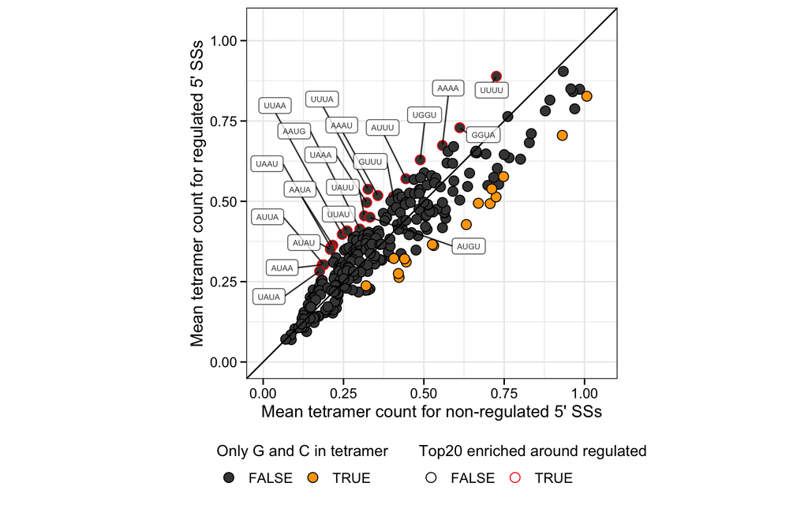

```r
delta <- 0.1

canonicalWindow <- canonicalSS+50
nonRegCanonicalWindow <- nonRegCanonicalSS+50

canonicalWindowRSS <- RNAStringSet(getSeq(Hsapiens, canonicalWindow))
nonRegCanonicalWindowRSS <- RNAStringSet(getSeq(Hsapiens, nonRegCanonicalWindow))

tetramerDF <- data.frame(regulated = oligonucleotideFrequency(canonicalWindowRSS, 4) %>% colMeans(),
                         nonRegulated = oligonucleotideFrequency(nonRegCanonicalWindowRSS, 4) %>% colMeans(),
                         tetramer = oligonucleotideFrequency(RNAStringSet(), 4) %>% colnames) %>%
    mutate(delta = regulated - nonRegulated) %>%
    mutate(set = ifelse(delta >= 0, "regulated", "nonRegulated")) %>%
    group_by(set) %>%
    arrange(desc(abs(delta))) %>%
    mutate(id=1:dplyr::n()) %>%
    ungroup

plotDF <- tetramerDF

plotDF$onlyGC = TRUE
plotDF$onlyGC[grepl("A", plotDF$tetramer)] <- FALSE
plotDF$onlyGC[grepl("U", plotDF$tetramer)] <- FALSE

plotDF <- plotDF %>%
    mutate(tetramer = ifelse(id > 20, "", tetramer)) %>%
    mutate(tetramer = ifelse(set == "nonRegulated", "", tetramer))

plotDF <- plotDF %>% mutate(enrichedInReg = ifelse(tetramer != "", T, F))


p <- plotDF %>%
    arrange(onlyGC) %>%
    ggplot(., aes(x=nonRegulated, y=regulated, fill=onlyGC)) +
        geom_point(mapping = aes(color=enrichedInReg), pch=21, size=3) +
        geom_abline(slope=1, intercept=0) +
        scale_color_manual(values=c("TRUE" = "red",
                                    "FALSE" = "black")) +
        scale_fill_manual(values=c("TRUE"="orange",
                                    "FALSE" = "#444444")) +
        ggrepel::geom_label_repel(mapping=aes(x=nonRegulated, y=regulated, label=tetramer), size=2, alpha=.8, inherit.aes = FALSE, max.overlaps=Inf, min.segment.length=.1, box.padding = .2, force=100) +
        labs(x="Mean tetramer count for non-regulated 5' SSs",
             y="Mean tetramer count for regulated 5' SSs") +
        coord_cartesian(xlim=c(0, 1.05), ylim=c(0, 1.05)) +
        theme(plot.title = element_text(size = 10, hjust=.5)) +
        guides(fill = guide_legend(title="Only G and C in tetramer", title.position = "top", title.hjust = 0.5, ncol=2),
               color = guide_legend(title="Top20 enriched around regulated", title.position = "top", title.hjust = 0.5, ncol=2)) +
        myTheme +
        theme(aspect.ratio = 1/1,
              legend.position = "bottom")

p
```

The top20 enriched tetramers for the regulated and non-regulated splice sites were then used for the generation of a motif, by first making a multiple sequence alignment and subsequently transfering the alignment into a logo plot.

```r
library(msa)
library(ggseqlogo)

p1 <- tetramerDF %>%
    dplyr::filter(set == "regulated" & id <= 20) %>% pull(tetramer) %>% RNAStringSet() %>%
    msaClustalW(inputSeqs = .) %>%
    {
        ggplot() + geom_logo(as.character(.), seq_type="rna") +
            coord_cartesian(ylim=c(0,2)) +
            myTheme +
            theme(panel.grid = element_blank(),
                  panel.border = element_blank(),
                  axis.line = element_line(colour = "black"),
                  plot.title = element_text(size=8),
                  aspect.ratio = 1/2) +
            labs(title="Based on tetramers enriched around\nregulated canonical A5SSs")
    }
```

```
## use default substitution matrix
```

```r
p2 <- tetramerDF %>% dplyr::filter(set == "nonRegulated" & id <= 20) %>% pull(tetramer) %>% RNAStringSet() %>%
    msaClustalW(inputSeqs = .) %>%
    {
        ggplot() + geom_logo(as.character(.), seq_type="rna") +
            coord_cartesian(ylim=c(0,2)) +
            myTheme +
            theme(panel.grid = element_blank(),
                  panel.border = element_blank(),
                  axis.line = element_line(colour = "black"),
                  plot.title = element_text(size=8),
                  aspect.ratio = 1/2) +
            labs(title="Based on tetramers enriched around\nnon-regulated canonical A5SSs")
    }
```

```
## use default substitution matrix
```

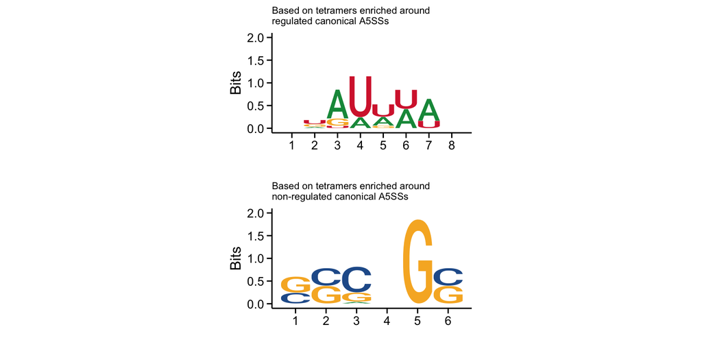

```r
egg::ggarrange(p1, p2, nrow=2)
```

## 7.2 Features

As a final step, canonical and alternative splice sites as well as regulated and non-regulated splice sites were compared for their splice site strength. In addition, the intron length and intronic GC content was compared based on the canonical splice sites.

```r
library(VarCon)
library(ggbeeswarm)
calc_splicesite_strength <- function(gr, set, A5SS){
    strengths <- gr %>%
        flank(., 6, start = FALSE) %>% promoters(., upstream = 3, downstream = 6) %>%
        getSeq(Hsapiens, .) %>%
        as.character() %>%
        VarCon::calculateMaxEntScanScore(., 5) %>%
        as.numeric()

    return(
        data.frame(
            set,
            A5SS,
            strength = strengths,
            event_id = gr$event_id,
            exon=gr$exon
        )
    )
}


spliceSiteStrengthDF <- rbind(
    calc_splicesite_strength(canonicalSS, "regulated", "canonical"),
    calc_splicesite_strength(alternativeSS, "regulated", "alternative"),
    calc_splicesite_strength(nonRegCanonicalSS, "non-regulated", "canonical"),
    calc_splicesite_strength(nonRegAlternativeSS, "non-regulated", "alternative")
)

p_splicesite_strength1 <- spliceSiteStrengthDF %>%
    ggplot(., aes(x=set, y=strength)) +
        ggrastr::rasterise(geom_quasirandom(color="darkgrey"), dpi=300) +
        geom_boxplot(alpha=.5, outlier.size = -1, col="black") +
        facet_wrap(~A5SS, ncol=2) +
        coord_cartesian(ylim=c(-35,15)) +
        ggpubr::stat_compare_means(label.y = 14, size=3) +
        labs(y="Splice site strength") +
        myTheme +
        theme(aspect.ratio = 1.5/1,
              axis.text.x = element_text(angle=45, hjust = 1, vjust=1))

p_splicesite_strength2 <- spliceSiteStrengthDF %>%
    ggplot(., aes(x=A5SS, y=strength)) +
        ggrastr::rasterise(geom_quasirandom(color="darkgrey"), dpi=300) +
        geom_boxplot(alpha=.5, outlier.size = -1, col="black") +
        facet_wrap(~set, ncol=2) +
        coord_cartesian(ylim=c(-35,15)) +
        ggpubr::stat_compare_means(label.y = 14, size=3) +
        labs(y="Splice site strength") +
        myTheme +
        theme(aspect.ratio = 1.5/1,
              axis.text.x = element_text(angle=45, hjust = 1, vjust=1))
```

```r
introns <- endoapply(A5SSranges[names(A5SSranges) %in% canonicalSS$event_id], function(gr){
    canonical <- canonicalSS$exon[canonicalSS$event_id == gr$event_id[1]]
    gr <- gr %>% plyranges::filter(exon %in% c(canonical, "E2")) %>% gaps(., start=NA, end=NA)
    gr$event_id <- gr$event_id[1]
    gr$set <- "regulated"
    gr$A5SS <- ifelse(canonical == "E1D", "distal", "proximal")
    return(gr)
}) %>% unlist

nonRegIntrons <- endoapply(nonRegulatedA5SSranges[names(nonRegulatedA5SSranges) %in% nonRegCanonicalSS$event_id], function(gr){
    canonical <- nonRegCanonicalSS$exon[nonRegCanonicalSS$event_id == gr$event_id[1]]
    gr <- gr %>% plyranges::filter(exon %in% c(canonical, "E2")) %>% gaps(., start=NA, end=NA)
    gr$event_id <- gr$event_id[1]
    gr$set <- "non-regulated"
    gr$A5SS <- ifelse(canonical == "E1D", "distal", "proximal")
    return(gr)
}) %>% unlist

p_intron_length <- c(introns, nonRegIntrons) %>%
    as.data.frame() %>%
    ggplot(., aes(x=set, y=width)) +
        ggrastr::rasterise(geom_quasirandom(color="darkgrey"), dpi=300) +
        geom_boxplot(alpha=.5, outlier.size = -1, col="black") +
        ggpubr::stat_compare_means(label.y = 6, size=3) +
        scale_y_log10() +
        labs(y="Intron length") +
        myTheme +
        theme(aspect.ratio=2/1,
              axis.text.x = element_text(angle=45, hjust = 1, vjust=1))
```

```r
GCcont <- introns %>%
    getSeq(Hsapiens, .) %>%
    alphabetFrequency(., baseOnly=TRUE, as.prob = T) %>%
    as.data.frame() %>%
    dplyr::select(C,G) %>%
    rowSums

nonRegGCcont <- nonRegIntrons %>%
    getSeq(Hsapiens, .) %>%
    alphabetFrequency(., baseOnly=TRUE, as.prob = T) %>%
    as.data.frame() %>%
    dplyr::select(C,G) %>%
    rowSums



p_GC_content <- data.frame(set=c(rep("regulated", length(GCcont)), rep("non-regulated", length(nonRegGCcont))),
                 GC = c(GCcont, nonRegGCcont),
                 A5SS=c(introns$A5SS, nonRegIntrons$A5SS)) %>%
    ggplot(., aes(x=set, y=GC)) +
        ggrastr::rasterise(geom_quasirandom(color="darkgrey"), dpi=300) +
        geom_boxplot(alpha=.5, outlier.size = -1, col="black") +
        ggpubr::stat_compare_means(label.y = .9, size=3) +
        labs(y="GC content") +
        myTheme +
        theme(aspect.ratio=2/1,
              axis.text.x = element_text(angle=45, hjust = 1, vjust=1))
```

```r
egg::ggarrange(
    p_splicesite_strength1,
    p_intron_length,
    p_splicesite_strength2,
    p_GC_content,
    ncol=2,
    widths=c(1,.5)
)
```

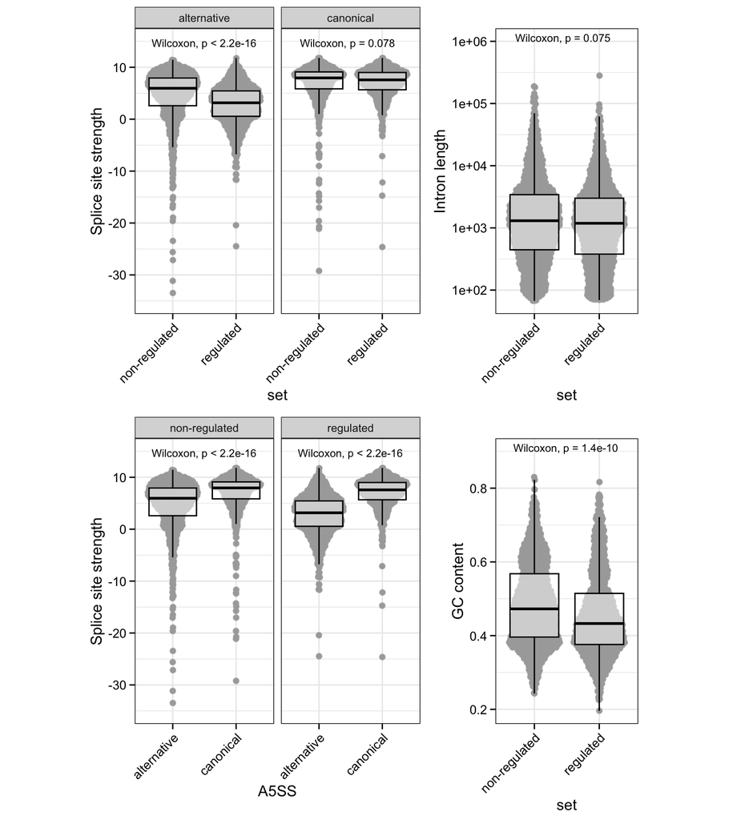